# PML Course Project

Alejandro Correa

Sunday, April 26, 2015

## **How you built your model?**

**1. Problem and Data understanding:** Read the paper: Velloso, E.; Bulling, A.;Gellersen, H.; Ugulino, W.; Fuks, H. *Qualitative Activity Recognition of Weight Lifting Exercises*. Proceedings of 4th International Conference in Cooperation withSIGCHI (Augmented Human ’13) . Stuttgart, Germany: ACM SIGCHI, 2013.

**2. Data preparation:** The analytic technologies that we can bring to bear are powerful but they impose certain requirements on the data they use. They often require data to be in a form different from how the data are provided naturally, and some conversion will be necessary. Explore the data. In our case, we must get rid of blank cells and weird text like “#DIV/0!”. Eliminate no relevant variables (names, time, etc…) , columns with zero variance or many NA’s, (e.x.: more than 19,000 NA’s). Optionally, depending of the method you are going to use you should normalize or scale the data.

[output not shown]

Original data dimensions:

```
## [1] 19622   160
```

After cleaning data dimensions:

```
## [1] 19622    54
```

### Single Tree model statistics:

```r
inTrain = createDataPartition(y=training$classe,p=0.7, list=FALSE)
data.Train = training[inTrain,]
data.Test = training[-inTrain,]
modFit.rpart = train(classe ~ ., method="rpart", data=data.Train)
print(modFit.rpart$finalModel)
```

```
## n= 13737
##
## node), split, n, loss, yval, (yprob)
##       * denotes terminal node
##
##  1) root 13737 9831 A (0.28 0.19 0.17 0.16 0.18)
##    2) roll_belt< 130.5 12576 8679 A (0.31 0.21 0.19 0.18 0.11)
##      4) pitch_forearm< -33.6 1104   10 A (0.99 0.0091 0 0 0) *
##      5) pitch_forearm>=-33.6 11472 8669 A (0.24 0.23 0.21 0.2 0.12)
##       10) num_window>=45.5 10951 8148 A (0.26 0.24 0.22 0.2 0.088)
##         20) magnet_dumbbell_y< 439.5 9316 6565 A (0.3 0.19 0.25 0.19 0.082)
##           40) num_window< 241.5 2237  910 A (0.59 0.14 0.12 0.11 0.032) *
##           41) num_window>=241.5 7079 5033 C (0.2 0.2 0.29 0.21 0.097)
##             82) magnet_dumbbell_z< -26.5 1622  579 A (0.64 0.21 0.061 0.07 0.016) *
##             83) magnet_dumbbell_z>=-26.5 5457 3510 C (0.07 0.2 0.36 0.25 0.12) *
##         21) magnet_dumbbell_y>=439.5 1635  732 B (0.032 0.55 0.046 0.25 0.12) *
##       11) num_window< 45.5 521  108 E (0 0 0 0.21 0.79) *
##    3) roll_belt>=130.5 1161    9 E (0.0078 0 0 0 0.99) *
```

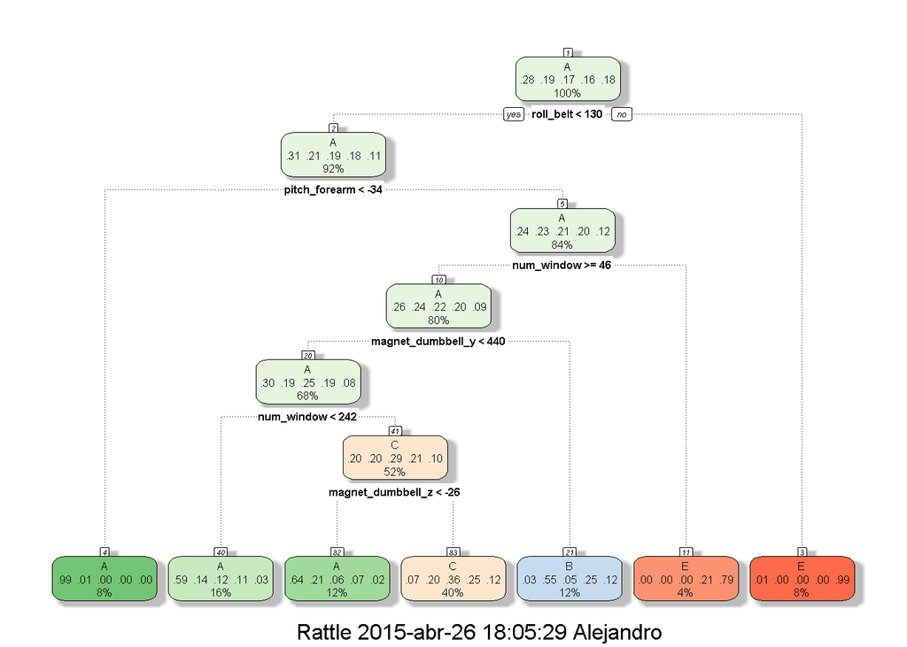

We use the Test data to measure our single tree model performance:

```r
pred.Test = predict(modFit.rpart,newdata=data.Test)
confusionMatrix(pred.Test,data.Test$classe)
```

```
## Confusion Matrix and Statistics
##
##           Reference
## Prediction    A    B    C    D    E
##          A 1473  290  155  171   42
##          B   29  383   33  162   76
##          C  167  466  838  593  325
##          D    0    0    0    0    0
##          E    5    0    0   38  639
##
## Overall Statistics
##
##                Accuracy : 0.5664
##                  95% CI : (0.5536, 0.5791)
##     No Information Rate : 0.2845
##     P-Value [Acc > NIR] : < 2.2e-16
##
##                   Kappa : 0.4458
##  Mcnemar's Test P-Value : < 2.2e-16
##
## Statistics by Class:
##
##                      Class: A Class: B Class: C Class: D Class: E
## Sensitivity            0.8799  0.33626   0.8168   0.0000   0.5906
## Specificity            0.8437  0.93679   0.6808   1.0000   0.9910
## Pos Pred Value         0.6912  0.56076   0.3508      NaN   0.9370
## Neg Pred Value         0.9465  0.85467   0.9462   0.8362   0.9149
## Prevalence             0.2845  0.19354   0.1743   0.1638   0.1839
## Detection Rate         0.2503  0.06508   0.1424   0.0000   0.1086
## Detection Prevalence   0.3621  0.11606   0.4059   0.0000   0.1159
## Balanced Accuracy      0.8618  0.63652   0.7488   0.5000   0.7908
```

### Random Forest model statistics:

Due the hard computing time I will omit the code processing in the making of this document for this model:

```r
set.seed(18283)
modFit.rf = train(classe ~ ., method="rf", data=data.Train)
```

```
##  Random Forest

##  13737 samples
##  53 predictor
##  5 classes: 'A', 'B', 'C', 'D', 'E'

##  No pre-processing
##  Resampling: Bootstrapped (25 reps)

##  Summary of sample sizes: 13737, 13737, 13737, 13737, 13737, 13737, ...

##  Resampling results across tuning parameters:

##    mtry  Accuracy   Kappa      Accuracy SD  Kappa SD
##     2    0.9915538  0.9893167  0.001892914  0.002392660
##    27    0.9953497  0.9941182  0.001157793  0.001464180
##    53    0.9915516  0.9893150  0.003183247  0.004023367

##  Accuracy was used to select the optimal model using  the largest value.
##  The final value used for the model was mtry = 27.
```

```r
pred.Test = predict(modFit.rf,data.Test)
confusionMatrix(pred.Test,data.Test$classe)
```

```
##  Confusion Matrix and Statistics

##  Reference
##  Prediction    A    B    C    D    E
##           A 1674    4    0    0    0
##           B    0 1134    4    0    0
##           C    0    0 1022    3    0
##           D    0    1    0  960    0
##           E    0    0    0    1 1082

##  Overall Statistics

##  Accuracy : 0.9978
##  95% CI : (0.9962, 0.9988)
##  No Information Rate : 0.2845
##  P-Value [Acc > NIR] : < 2.2e-16

##  Kappa : 0.9972
##  Mcnemar's Test P-Value : NA

##  Statistics by Class:

##                       Class: A Class: B Class: C Class: D Class: E
##  Sensitivity            1.0000   0.9956   0.9961   0.9959   1.0000
##  Specificity            0.9991   0.9992   0.9994   0.9998   0.9998
##  Pos Pred Value         0.9976   0.9965   0.9971   0.9990   0.9991
##  Neg Pred Value         1.0000   0.9989   0.9992   0.9992   1.0000
##  Prevalence             0.2845   0.1935   0.1743   0.1638   0.1839
##  Detection Rate         0.2845   0.1927   0.1737   0.1631   0.1839
##  Detection Prevalence   0.2851   0.1934   0.1742   0.1633   0.1840
##  Balanced Accuracy      0.9995   0.9974   0.9977   0.9978   0.9999
```

## **How you used cross validation?**

I used a Set Validation Approach on the data with the help of the “CARET” package, 70% Training and 30% Test. The accuracy in the test data, give us the real performance of the model. This was applied both for the single tree model and the random forest.

## **What you think the expected out of sample error is?**

The misclassification rate in the Test data give us a more precise idea of our model performance. Random Forest out sample error: 1 - 0.9978 = 0.0022

## **Why you made the choices you did?**

**Cross-validation:** this will give us a more precise idea of the real performance of our models. Given the flexibility of the implemented models, this implied low bias but high variance, so to reduce the variance problem is important to work with a large sample data. A training data of 70% of the obs works well for this purpose. **Model selection:** the random forest model use bagging on decorrelating trees helping also with the variance problem.